# 100WomenandMen

Isabel DAlessandro, Sanika Bapat, Zoe Wiles CS 234

## Famous Men and Women on Wikipedia

The goal of this project is to answer the question: Do Wikipedia biographies of famous women differ in popularity/notability from the Wikipedia biographies of famous men?

To answer this question, we first generated a list of the top 100 most famous' women and men using Google's PageRank(see here: http://wikirank-2016.di.unimi.it/).

### Load in the names of the top 100 men and women

```python
with open("100women.csv","r") as inFile: #read the file back in
    women100=[elem.strip() for elem in inFile ]
```

```python
with open("100men.csv","r") as inFile: #read the file back in
    men100=[elem.strip() for elem in inFile]
```

### Setup

```python
#import necessary packages
import matplotlib.pyplot as plt
%matplotlib inline
plt.style.use('ggplot')
import numpy as np

# install mwclient for reading Wikipedia data
!pip install mwclient

# test the installation
import mwclient

#supress warnings in jupytr
import warnings
warnings.filterwarnings(action='ignore')

#Set Wikipedia as a site
from mwclient import Site
site = Site('en.wikipedia.org')
```

### Get the Wikipedia pages for the top 100 women and men

```python
women100Pages={}
for woman in women100:
    women100Pages[woman]=site.pages[woman]
```

```python
men100Pages={}
for man in men100:
    men100Pages[man]=site.pages[man]
```

### Get the number of backlinks for the top 100 women and men

```python
women100backlinks=[]
for woman in women100Pages:
    women100backlinks.append(len([el for el in women100Pages[woman].backlinks()]))
```

```python
men100backlinks=[]
for man in men100Pages:
    men100backlinks.append(len([el for el in men100Pages[man].backlinks()]))
```

### Plot a histogram of the distribution of the number of backlinks for the top 100 women and men

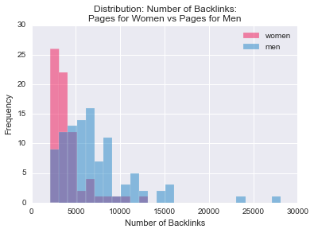

```python
#Histograms
binwidth=1000
binspef=range(min(men100backlinks), max(men100backlinks) + binwidth, binwidth)
plt.hist(women100backlinks,bins=binspef,alpha=0.5,label='women',color='#F01356')
plt.hist(men100backlinks,bins=binspef,alpha=0.5,label='men',color='#2285C7')
plt.legend(loc='upper right')
plt.ylabel('Frequency')
plt.xlabel('Number of Backlinks')
plt.title('Distribution: Number of Backlinks: '+'\n'+'Pages for Women vs Pages for Men')
plt.show()
```

### Get the means and standard deviations for the number of backlinks

```python
women100backlinks_mean=np.mean(women100backlinks)
men100backlinks_mean=np.mean(men100backlinks)
women100backlinks_std=np.std(women100backlinks)
men100backlinks_std=np.std(men100backlinks)
```

### Run a t-test

```python
import scipy.stats as stats
stats.ttest_ind(women100backlinks,men100backlinks,equal_var=False)
```

```
Ttest_indResult(statistic=-8.2696721463746492, pvalue=8.6390191845530699e-14)
```

### Plot the means- Backlinks

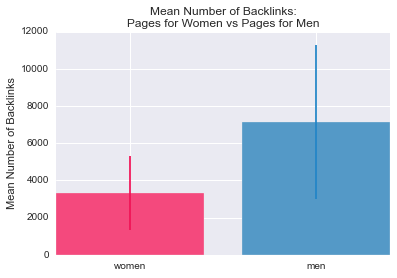

```python
plt.bar([0],women100backlinks_mean,color='#F4497D',yerr=women100backlinks_std,ecolor='#F01356')
plt.bar([1],men100backlinks_mean,color='#5499C7',yerr=men100backlinks_std,ecolor='#2285C7')
labels=['women','men']
plt.xticks([i + 0.4 for (i, m) in enumerate(labels)], labels)
plt.ylabel('Mean Number of Backlinks')
plt.title('Mean Number of Backlinks: '+'\n'+'Pages for Women vs Pages for Men')
plt.show()
```

### Get the number of revisions for the pages of the top 100 women and men

```python
women100revisions=[]
for woman in women100Pages:
    women100revisions.append(len([el for el in women100Pages[woman].revisions()]))
```

```python
men100revisions=[]
for man in men100Pages:
    men100revisions.append(len([el for el in men100Pages[man].revisions()]))
```

### Plot a historgram of the distribution of the number of revisions for these pages

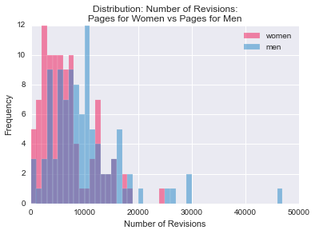

```python
#Histogram - revisions
binwidth=1000
binspef=range(min(men100revisions), max(men100revisions) + binwidth, binwidth)
plt.hist(women100revisions,bins=binspef,alpha=0.5,label='women',color='#F01356')
plt.hist(men100revisions,bins=binspef,alpha=0.5,label='men',color='#2285C7')
plt.legend(loc='upper right')
plt.ylabel('Frequency')
plt.xlabel('Number of Revisions')
plt.title('Distribution: Number of Revisions: '+'\n'+'Pages for Women vs Pages for Men')
plt.show()
```

```python
women100revisions_mean=np.mean(women100backlinks)
men100revisions_mean=np.mean(men100backlinks)
women100revisions_std=np.std(women100backlinks)
men100revisions_std=np.std(men100backlinks)
```